# Fisheries Conservation Features

### Fisheries conservation features

The following were used in this study:

1. Distribution of selected bycatch species
2. Distribution of larval spawning grounds of selected commercially targeted species

#### Bycatch distribution

First, we compiled a list of bycatch reported in the Pacific ABNJ. Then, we used the **IUCN** distribution maps for these species. These polygons are from the IUCN Red List, showing the known ranges of the species (IUCN Red List, 2021).

We limited the bycatch included in this study to **sea turtles**, but this workflow can be easily replicated and expanded to include more species.

The following were the sea turtles reported as bycatch and intersected with the study area:

- Loggerhead turtle (*Caretta caretta*)
- Green turtle (*Chelonia mydas*)
- Leatherback turtle (*Dermochelys coriacea*)
- Hawksbill turtle (*Eretmochelys imbricata*)
- Olive ridley turtle (*Lepidochelys olivacea*)

The relevant scripts for creating the bycatch distribution layer are labeled with a prefix of `04_IUCN` in `~/scripts/`.

The plots below show the distribution of these species using `fIUCNINtersect()`.

```r
# the function is found in:
source("scripts/04a_IUCN_fIUCNINtersect.R")
# the function is ran in:
source("scripts/04b_IUCN_fIUCNIntersectRun.R")
```

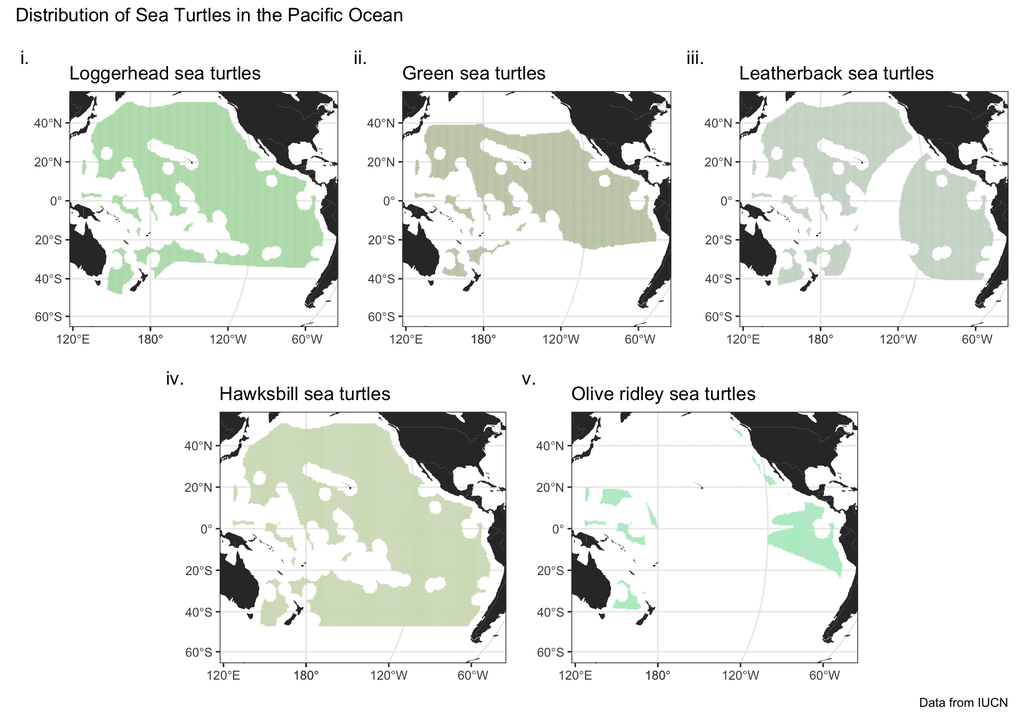

#### Spawning grounds of commercially targeted species

Just like the bycatch layer, we compiled a list of commercially targeted large pelagic species managed in the Pacific from different sources. From this list, we have 4 species with available data on their global larval spawning grounds:

- Yellowfin Tuna (*Thunnus albacares*)
- Albacore (*Thunnus alalunga*)
- Skipjack Tuna (*Katsuwonus pelamis*)
- Swordfish (*Xiphias gladius*)

The models for these species are from a report by Mercer (2019) where he created Generalized Additive Models (GAMs) to predict spawning grounds using (Nishikawa et al., 1985). He used mean seasonal abundance from a historical dataset of plankton tows of fish larvae (dated back to the 1950s), and oceanographic and environmental conditions from global databases.

We reran his models (see scripts labeled with a prefix `05a_Commercial` in `~/scripts/` for complete reruns) and used the medians of the predictions for each species as probability thresholds to create the distribution maps and the function `fCommercialFeat()`.

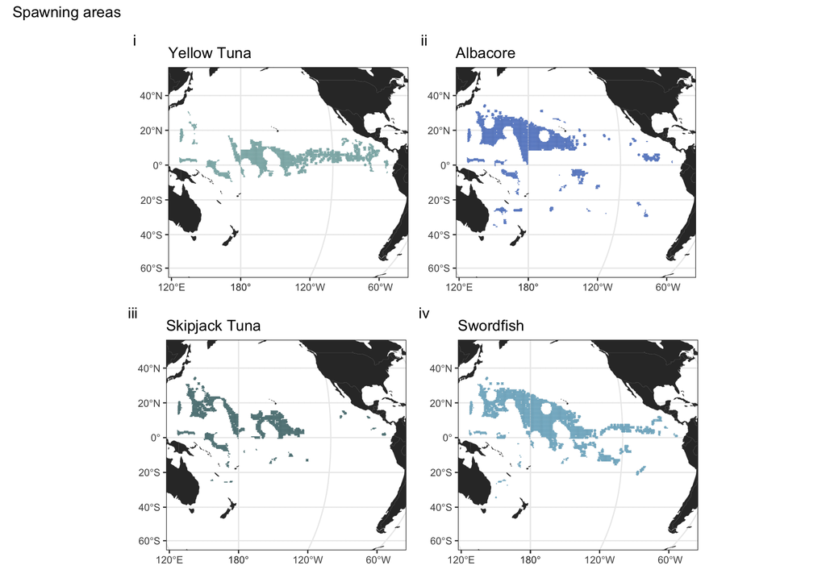

```r
# to intersect the results of the GAMs with the PUs
# the function is in:
source("scripts/05b_Commercial_fCommercialFeat.R")
# the function is ran at:
source("scripts/05c_Commercial_fCommercialFeatRun.R")
global_plots
```

This is an example of how the data looks like (so far) for bycatch:

```r
head(bycatch)
```

```
## Simple feature collection with 6 features and 2 fields
## Geometry type: POLYGON
## Dimension:     XY
## Bounding box:  xmin: -3779074 ymin: 168708.9 xmax: -3695824 ymax: 473118.3
## CRS:           +proj=robin +lon_0=180 +x_0=0 +y_0=0 +ellps=WGS84 +datum=WGS84 +units=m +no_defs
## # A tibble: 6 x 3
##   cellsID                                                geometry species
##     <int>                                           <POLYGON [m]> <chr>
## 1       1 ((-3751324 216773.5, -3779074 232795.1, -3779074 26483… Caretta_caret…
## 2       2 ((-3751324 312902.8, -3779074 328924.4, -3779074 36096… Caretta_caret…
## 3       3 ((-3751324 409032.1, -3779074 425053.6, -3779074 45709… Caretta_caret…
## 4       4 ((-3723574 168708.9, -3751324 184730.5, -3751324 21677… Caretta_caret…
## 5       5 ((-3723574 264838.2, -3751324 280859.7, -3751324 31290… Caretta_caret…
## 6       6 ((-3723574 360967.5, -3751324 376989, -3751324 409032.… Caretta_caret…
```

And for the large pelagics:

```r
head(pelagic)
```

```
## Simple feature collection with 6 features and 2 fields
## Geometry type: POLYGON
## Dimension:     XY
## Bounding box:  xmin: -3779074 ymin: 168708.9 xmax: -3695824 ymax: 473118.3
## CRS:           +proj=robin +lon_0=180 +x_0=0 +y_0=0 +ellps=WGS84 +datum=WGS84 +units=m +no_defs
## # A tibble: 6 x 3
##   cellsID                                                       geometry species
##     <int>                                                  <POLYGON [m]> <chr>
## 1       1 ((-3751324 216773.5, -3779074 232795.1, -3779074 264838.2, -3… ALB
## 2       2 ((-3751324 312902.8, -3779074 328924.4, -3779074 360967.5, -3… ALB
## 3       3 ((-3751324 409032.1, -3779074 425053.6, -3779074 457096.7, -3… ALB
## 4       4 ((-3723574 168708.9, -3751324 184730.5, -3751324 216773.5, -3… ALB
## 5       5 ((-3723574 264838.2, -3751324 280859.7, -3751324 312902.8, -3… ALB
## 6       6 ((-3723574 360967.5, -3751324 376989, -3751324 409032.1, -372… ALB
```

Each `sf` object has the following columns:

- `cellsID` is the unique ID for each hexagonal PU
- `species` is the species code (e.g. ALB = Albacore)
- `geometry`